# GSA Competition

Ryan Tuggle and Jessica Bonnie

April 13, 2016

This R Markdown document shows an initial exploration of GSA contracting competition data. See end for summary section containing notes and questions for next iteration.

```r
#load libraries silently.

require(dplyr)
require(ggplot2)
require(pander)
```

## Kristin’s Data

Currently this section is merely trying to reproduce Ryan’s steps from his data set, which are included in the next section.

```r
# Load data into single frame from multiple CSV files in directory.


#Directory of files from Kristin, filenames contain numerical date information that we will want to capture.
datadir <- './data/FPDS_20160413'

reading_helper <- function(infile,datadir,...){
  ## Function to read in csv and strip date information from file name
  temp <- read.csv(paste(datadir,infile,sep="/"), stringsAsFactors = F,...)
  temp$period <- gsub("FPDS","",infile) %>% gsub("\\.csv","",.)
  return(temp)
}

#if (exists(fpds)){rm(fpds)}


files <- list.files(datadir,pattern = "FPDS[0-9_]*.csv")
fpds <- do.call(rbind, lapply(files, function(x) reading_helper(x,datadir)))

#Here are the column headers in the data.frame
names(fpds)
```

```
##  [1] "Contracting.Agency.ID"
##  [2] "Contracting.Agency.Name"
##  [3] "Contracting.Department.ID"
##  [4] "Contracting.Department.Name"
##  [5] "Contracting.Office.ID"
##  [6] "Contracting.Office.Name"
##  [7] "Contracting.Office.Region"
##  [8] "PIID"
##  [9] "Modification.Number"
## [10] "Referenced..IDV.PIID"
## [11] "Referenced.IDV.Mod.Number"
## [12] "Date.Signed"
## [13] "Effective.Date"
## [14] "Est..Ultimate.Completion.Date"
## [15] "Completion.Date"
```

[output cut: 22 more lines]

This data has already been filtered to have only GSA as the Contracting Department.

```r
## Adapt numeric columns to be numbers without all the extra garbage characters

fpds$Action.Obligation <- gsub("[^0-9.]","",fpds$Action.Obligation) %>% as.numeric()


## Select Desired Variables

fpds <- fpds %>% select(Referenced..IDV.PIID, PIID, Referenced.IDV.Mod.Number, Modification.Number, Date.Signed, Action.Obligation, Contracting.Agency.ID, Contracting.Office.ID, Contracting.Office.Name, Award.or.IDV.Type, Contracting.Agency.Name, Funding.Office.Name, Funding.Agency.Name, Place.of.Performance.Zip.Code, Type.of.Contract, Global.DUNS.Number, Type.of.Set.Aside, period)


## Create any new variables we might need
fpds <- fpds %>% mutate(cat = paste(Referenced..IDV.PIID, PIID, sep='-'))

# The following variables removed from selection list due to not being present in the current pull: Extent.Competed, Number.of.Offers.Received, Other.Than.Full.and.Open.Competition, Actions, Fiscal.Year, Number.of.Records
```

Take a look at how the extent competed variable is aggregated across mods. One goal is to understand how to sum up the competition variables such as the Number of Offers Received.

```r
# We do not currently have the columns necessary for this:
# fpds.test1 <- fpds %>% filter(Number.of.Records > 1 | Actions > 1)


#group variables by PIIDs
fpds.test2 <- fpds %>% group_by(cat) %>%
    summarize(cnt = n_distinct(cat)) %>%
    arrange(desc(cnt)) %>%
    filter(cnt > 1)

#This is empty just like in Ryan's set
head(fpds.test2)
```

```
## Source: local data frame [0 x 2]
##
## Variables not shown: cat (chr), cnt (int)
```

```r
#does any PIID have a mod in this set?
fpds.test3 <- fpds %>% filter(Modification.Number != 0) %>%
  select(-Date.Signed,-Contracting.Office.ID,-Contracting.Agency.ID,
         -Funding.Agency.Name,-Funding.Office.Name,-Contracting.Agency.Name,
         -Global.DUNS.Number,-Place.of.Performance.Zip.Code,-Type.of.Set.Aside)
pander(tbl_df(sample_n(fpds.test3, 20)),split.cells = 15)
```

Table continues below

| Referenced..IDV.PIID | PIID | Referenced.IDV.Mod.Number |
| --- | --- | --- |
|  | GS00F007BA |  |
|  | GS23F0008K |  |
|  | GS35F0096X |  |
|  | GS07F0353T |  |
| GS00P13CYA0133 | GSP0014CY5020 | PO03 |
|  | GS10F0322Y |  |
|  | GS07F201BA |  |
|  | GS10F0145T |  |
|  | GS00T07NSD0008 |  |
|  | GS11P15MAC0219 | 0 |
| GS21F0045U | GS04P11EWA0022 | 0 |
|  | GS35F0585J |  |
|  | GS23F058AA |  |
|  | GS35F0182P |  |
|  | GS35F0566X |  |
| GS09P09KSD0108 | GSP0914WD5066 | 0 |
|  | GS11P10NWP0063 | 0 |
|  | GS10F071BA |  |
|  | GS07F0227Y |  |
|  | GS02F0076U |  |

Table continues below

| Modification.Number | Action.Obligation | Contracting.Office.Name |
| --- | --- | --- |
| PA0002REASSIGNMENT | 0.00 | GSA/FAS MANAGEMENT SERVICES CENTER |
| PA0026ADMINPOC | 0.00 | GSA/FAS CENTER OF INNOVATIVE ACQUISITION DEV |
| PO0039PARTNUMCHG | 0.00 | GSA/FAS CENTER FOR IT SCHEDULE PROGRAM |
| PO0140EPANCPL | 0.00 | GSA/FAS GREATER SOUTHWEST ACQUISITION CTR (7FCO) |
| PS01 | 0.00 | ACQUISITION SERVICES DIV |
| PA0005EMAILCHG | 0.00 | GSA/FAS MANAGEMENT SERVICES CENTER |
| PA0002REASSIGNMENT | 0.00 | GSA/FAS GREATER SOUTHWEST ACQUISITION CTR (7FCO) |
| PA0014REASSIGNMENT | 0.00 | GSA/FAS MANAGEMENT SERVICES CENTER |
| PS1068 | 0.00 | GSA/FAS ITS/NETWORK SERVICES CONTRACT OPERATIONS DIVISION 1 |
| PC02 | 50144.67 | WPHCC - WEST O&M CONTRACTS BRANCH |
| PS11 | 0.00 | ACQUISITION DIVISION/SERVICES (SECTION A) |
| PO0074REVTERMCOND | 0.00 | GSA/FAS CENTER FOR IT SCHEDULE PROGRAM |
| PA0004REASSIGNMENT | 0.00 | GSA/FAS MANAGEMENT SERVICES CENTER |
| PO0008AUTHNEG | 0.00 | GSA/FAS CENTER FOR IT SCHEDULE PROGRAM |
| PA0007REASSIGNMENT | 0.00 | GSA/FAS CENTER FOR IT SCHEDULE PROGRAM |
| PS01 | 0.00 | SAN DIEGO SERVICE CENTER, HAWAII FIELD OFFICE |
| PA03 | 0.00 | WPHCB - EAST O&M CONTRACTS BRANCH |
| PA0010REASSIGNMENT | 0.00 | GSA/FAS MANAGEMENT SERVICES CENTER |
| PO0019PRCREDBASED | 0.00 | GSA/FAS GREATER SOUTHWEST ACQUISITION CTR (7FCO) |
| PA0036REASSIGNMENT | 0.00 | GSA/FAS NORTHEAST&CARIBBEAN SUPPLY AND ACQUISITION CENTER (2QSB) |

| Award.or.IDV.Type | Type.of.Contract | period | cat |
| --- | --- | --- | --- |
| FSS | FIRM FIXED PRICE | 092014 | -GS00F007BA |
| FSS | FIRM FIXED PRICE | 032015 | -GS23F0008K |
| FSS | FIRM FIXED PRICE | 072015_082015 | -GS35F0096X |
| FSS | FIXED PRICE WITH ECONOMIC PRICE ADJUSTMENT | 052015_062015 | -GS07F0353T |
| BPA CALL | FIRM FIXED PRICE | 072014_082014 | GS00P13CYA0133-GSP0014CY5020 |
| FSS | FIXED PRICE WITH ECONOMIC PRICE ADJUSTMENT | 052014_062014 | -GS10F0322Y |
| FSS | FIXED PRICE WITH ECONOMIC PRICE ADJUSTMENT | 032015 | -GS07F201BA |
| FSS | FIRM FIXED PRICE | 102015_112015 | -GS10F0145T |
| IDC | FIXED PRICE WITH ECONOMIC PRICE ADJUSTMENT | 072014_082014 | -GS00T07NSD0008 |
| DEFINITIVE CONTRACT | FIRM FIXED PRICE | 092015 | -GS11P15MAC0219 |
| BPA | FIXED PRICE WITH ECONOMIC PRICE ADJUSTMENT | 012015_022015 | GS21F0045U-GS04P11EWA0022 |
| FSS | FIRM FIXED PRICE | 072014_082014 | -GS35F0585J |
| FSS | FIRM FIXED PRICE | 072015_082015 | -GS23F058AA |
| FSS | FIRM FIXED PRICE | 102013_122013 | -GS35F0182P |
| FSS | FIRM FIXED PRICE | 092015 | -GS35F0566X |
| DELIVERY ORDER | FIRM FIXED PRICE | 012015_022015 | GS09P09KSD0108-GSP0914WD5066 |
| PURCHASE ORDER | FIRM FIXED PRICE | 052015_062015 | -GS11P10NWP0063 |
| FSS | FIXED PRICE WITH ECONOMIC PRICE ADJUSTMENT | 122015 | -GS10F071BA |
| FSS | FIXED PRICE WITH ECONOMIC PRICE ADJUSTMENT | 052015_062015 | -GS07F0227Y |
| FSS | FIXED PRICE WITH ECONOMIC PRICE ADJUSTMENT | 012015_022015 | -GS02F0076U |

Next let’s look at a few dimensions of the dataset.

Start with the count of records by contracting Agency

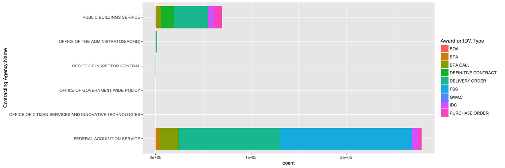

```r
#contracting agency

ggplot(fpds, aes(Contracting.Agency.Name)) +
    geom_bar(aes(fill = Award.or.IDV.Type)) +
    coord_flip()
```

Drill down to the offices within the Federal Acquisition Service.

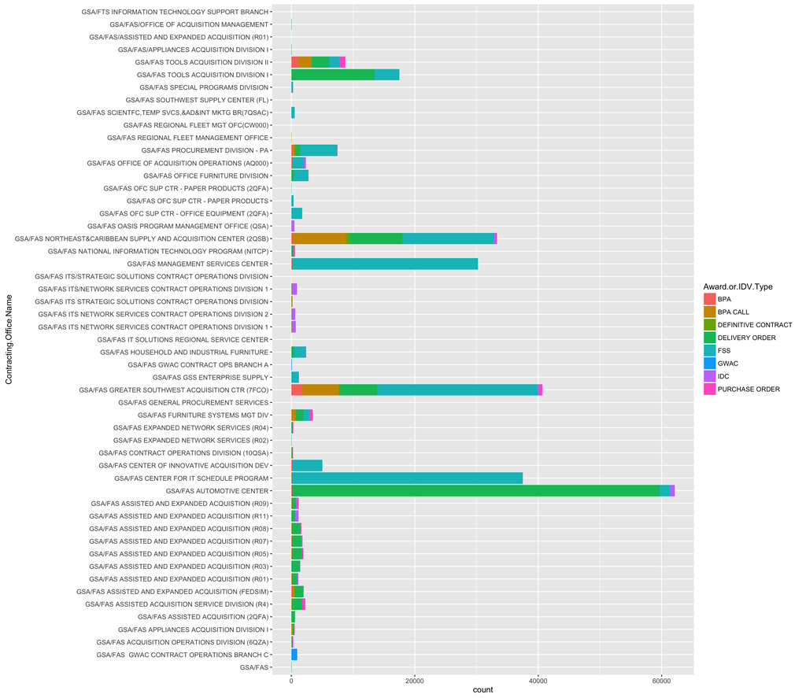

```r
#contracting agency

ggplot(filter(fpds, Contracting.Agency.Name == 'FEDERAL ACQUISITION SERVICE'),
              aes(Contracting.Office.Name)) +
    geom_bar(aes(fill = Award.or.IDV.Type)) +
    coord_flip()
```

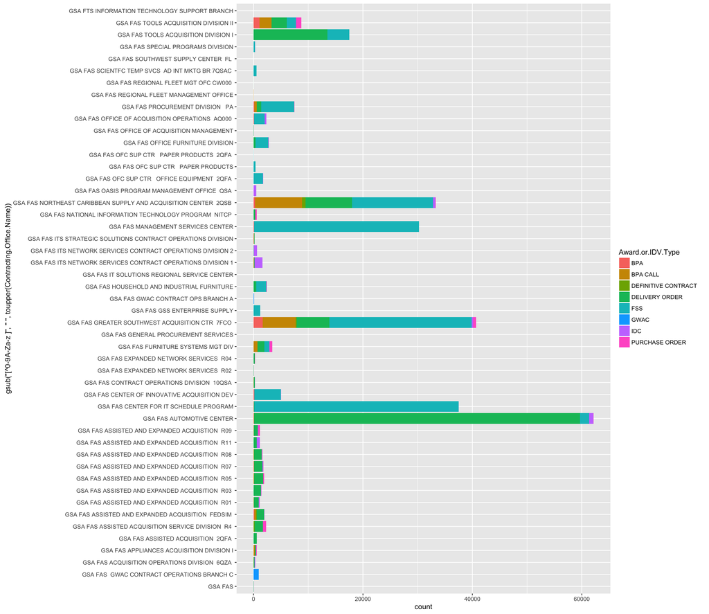

```r
# Let's try again, but this time strip the non-alphanumeric characters so that the contracting office names group even when one of them has a "/" in it.
ggplot(filter(fpds, Contracting.Agency.Name == 'FEDERAL ACQUISITION SERVICE'),
              aes(gsub("[^0-9A-Za-z ]"," ",toupper(Contracting.Office.Name)))) +
    geom_bar(aes(fill = Award.or.IDV.Type)) +
    coord_flip()
```

## Summary

### NOTES:

1. Need **Fiscal Year** Column to be be pulled… can be reconstructed from filenames, but that is problematic if more than one month is being included.
2. If there is a **Month** Column, please also include that. Failing that, let’s pull each month individually.
3. We may need these fields to be included in the next pull?
- `Extent.Competed`
- `Number.of.Offers.Received`
- `Other.Than.Full.and.Open.Competition`
- `Actions`
- `Number.of.Records`

## Ryan’s Data Extraction

Take a look at how the extent competed variable is aggregated across mods. One goal is to understand how to sum up the competition variables such as the Number of Offers Received.

```r
df <- read.csv('./data/GSA_Competition_Q1FY14.csv',stringsAsFactors = F)
names(df)
```

```
##  [1] "Modification.Number"
##  [2] "PIID"
##  [3] "PIID.Agency.ID"
##  [4] "Referenced..IDV.PIID"
##  [5] "Referenced.IDV.Agency.ID"
##  [6] "Referenced.IDV.Mod.Number"
##  [7] "Solicitation.ID"
##  [8] "Transaction.Number"
##  [9] "Date.Signed"
## [10] "Effective.Date"
## [11] "Est..Ultimate.Completion.Date"
## [12] "Fiscal.Year"
## [13] "Funding.Agency.ID"
## [14] "Funding.Agency.Name"
## [15] "Funding.Department.ID"
```

[output cut: 61 more lines]

```r
#select variables for exploration
dfs <- select(df, Referenced..IDV.PIID, PIID, Referenced.IDV.Mod.Number, Modification.Number, Date.Signed, Extent.Competed, Number.of.Offers.Received, Other.Than.Full.and.Open.Competition, Action.Obligation, Actions, Number.of.Records, Contracting.Office.Name, Award.or.IDV.Type, Contracting.Agency.Name)

dfs$Action.Obligation <- gsub("[^0-9.]","", dfs$Action.Obligation) %>% as.numeric()

dfs <- mutate(dfs,  cat = paste(Referenced..IDV.PIID, PIID, sep='-'))

test1 <- filter(dfs, Number.of.Records > 1 | Actions > 1)


#group variables by PIIDs
dfg <- group_by(dfs, cat)

test2 <- dfg %>%
    summarize(cnt = n_distinct(cat)) %>%
    arrange(desc(cnt)) %>%
    filter(cnt > 1)

head(test2)
```

```
## Source: local data frame [0 x 2]
##
## Variables not shown: cat (chr), cnt (int)
```

```r
#does any PIID have a mod in this set?
test3 <- filter(dfs, Modification.Number != 0)
pander(tbl_df(sample_n(test3, 20)),split.cells=15)
```

Table continues below

| Referenced..IDV.PIID | PIID | Referenced.IDV.Mod.Number |
| --- | --- | --- |
|  | GS35F446AA |  |
|  | GS35F0381L |  |
| GS07P99HHD0025 | GSP0713UR5126 | 0 |
| GS07P99HHD0080 | GSP0713UT5081 | 0 |
|  | GS07F0038H |  |
|  | GS07F0323W |  |
|  | GS11P11YMC0062 | 0 |
|  | GS35F0889N |  |
|  | GS35F0540U |  |
|  | GS21F0012Y |  |
|  | GS23F0094S |  |
|  | GS35F0105V |  |
|  | GS07F0380U |  |
|  | GS35F0177V |  |
|  | GS35F0236J |  |
|  | GS07F0008X |  |
|  | GS10F0068M |  |
|  | GS35F4748G |  |
| GS06F0026P | GSP0510SC0078 | 0 |
|  | GS07F0709X |  |

Table continues below

| Modification.Number | Date.Signed | Extent.Competed |
| --- | --- | --- |
| PS0026ADDPROD | 11/8/13 | FULL AND OPEN COMPETITION |
| PA0030DELPROD | 10/4/13 | NOT AVAILABLE FOR COMPETITION |
| PS01 | 10/29/13 | FULL AND OPEN COMPETITION |
| PS02 | 11/12/13 | FULL AND OPEN COMPETITION |
| PO0060EXERCISEOPTION | 12/11/13 | FULL AND OPEN COMPETITION |
| PA0004CANCELCONT | 10/1/13 | FULL AND OPEN COMPETITION AFTER EXCLUSION OF SOURCES |
| PS06 | 12/17/13 | FULL AND OPEN COMPETITION AFTER EXCLUSION OF SOURCES |
| PO0230PRCREDINDUST | 10/8/13 | FULL AND OPEN COMPETITION |
| PO0003TEMPEXTMAS | 12/3/13 | FULL AND OPEN COMPETITION |
| PA0008CANCELCONT | 12/5/13 | FULL AND OPEN COMPETITION |
| 2 | 12/11/13 | FULL AND OPEN COMPETITION |
| PA0017AUTHNEG | 11/12/13 | FULL AND OPEN COMPETITION |
| PO0064ADDPROD | 12/5/13 | FULL AND OPEN COMPETITION |
| PO0004EXERCISEOPTION | 12/11/13 | FULL AND OPEN COMPETITION |
| PA0018COOPERATPURCH | 12/16/13 | FULL AND OPEN COMPETITION |
| PA0023REASSIGNMENT | 10/8/13 | FULL AND OPEN COMPETITION |
| PO0018NAMEAGREECHG | 10/22/13 | FULL AND OPEN COMPETITION |
| PA1872AUTHNEG | 12/19/13 | FULL AND OPEN COMPETITION |
| PS10 | 10/24/13 | FULL AND OPEN COMPETITION |
| PA0005REASSIGNMENT | 10/4/13 | FULL AND OPEN COMPETITION |

Table continues below

| Number.of.Offers.Received | Other.Than.Full.and.Open.Competition |
| --- | --- |
| 999 |  |
| 999 |  |
| 3 |  |
| 3 |  |
| 21 |  |
| NA |  |
| 8 |  |
| 0 |  |
| NA |  |
| 999 |  |
| 0 |  |
| NA |  |
| NA |  |
| NA |  |
| 51 |  |
| NA |  |
| 999 |  |
| 51 |  |
| 6 |  |
| 999 |  |

Table continues below

| Action.Obligation | Actions | Number.of.Records | Contracting.Office.Name |
| --- | --- | --- | --- |
| 0.00 | 1 | 1 | GSA/FAS CENTER FOR IT SCHEDULE PROGRAM |
| 0.00 | 1 | 1 | GSA/FAS CENTER FOR IT SCHEDULE PROGRAM |
| 0.00 | 1 | 1 | GSA/PBS SOUTH CENTRAL TEXAS |
| 0.00 | 1 | 1 | GSA/PBS ARK/LA/TX SECTION |
| 0.00 | 1 | 1 | GSA/FAS GREATER SOUTHWEST ACQUISITION CTR (7FCO) |
| 0.00 | 1 | 1 | GSA/FAS GREATER SOUTHWEST ACQUISITION CTR (7FCO) |
| 0.00 | 1 | 1 | WPHBD - WEST REPAIR&ALTERATIONS CONTRACTS BRANCH |
| 0.00 | 1 | 1 | GSA/FAS CENTER FOR IT SCHEDULE PROGRAM |
| 0.00 | 1 | 1 | GSA/FAS CENTER FOR IT SCHEDULE PROGRAM |
| 0.00 | 1 | 1 | GSA/FAS TOOLS ACQUISITION DIVISION I |
| 0.00 | 1 | 1 | GSA/FAS MANAGEMENT SERVICES CENTER |
| 0.00 | 1 | 1 | GSA/FAS CENTER FOR IT SCHEDULE PROGRAM |
| 0.00 | 1 | 1 | GSA/FAS GREATER SOUTHWEST ACQUISITION CTR (7FCO) |
| 0.00 | 1 | 1 | GSA/FAS CENTER FOR IT SCHEDULE PROGRAM |
| 0.00 | 1 | 1 | GSA/FAS CENTER FOR IT SCHEDULE PROGRAM |
| 0.00 | 1 | 1 | GSA/FAS GREATER SOUTHWEST ACQUISITION CTR (7FCO) |
| 0.00 | 1 | 1 | GSA/FAS MANAGEMENT SERVICES CENTER |
| 0.00 | 1 | 1 | GSA/FAS CENTER FOR IT SCHEDULE PROGRAM |
| 86205.26 | 1 | 1 | ACQUISITION MANAGEMENT DIVISION |
| 0.00 | 1 | 1 | GSA/FAS GREATER SOUTHWEST ACQUISITION CTR (7FCO) |

| Award.or.IDV.Type | Contracting.Agency.Name | cat |
| --- | --- | --- |
| FSS | FEDERAL ACQUISITION SERVICE | -GS35F446AA |
| FSS | FEDERAL ACQUISITION SERVICE | -GS35F0381L |
| DELIVERY ORDER | PUBLIC BUILDINGS SERVICE | GS07P99HHD0025-GSP0713UR5126 |
| DELIVERY ORDER | PUBLIC BUILDINGS SERVICE | GS07P99HHD0080-GSP0713UT5081 |
| FSS | FEDERAL ACQUISITION SERVICE | -GS07F0038H |
| FSS | FEDERAL ACQUISITION SERVICE | -GS07F0323W |
| DEFINITIVE CONTRACT | PUBLIC BUILDINGS SERVICE | -GS11P11YMC0062 |
| FSS | FEDERAL ACQUISITION SERVICE | -GS35F0889N |
| FSS | FEDERAL ACQUISITION SERVICE | -GS35F0540U |
| FSS | FEDERAL ACQUISITION SERVICE | -GS21F0012Y |
| FSS | FEDERAL ACQUISITION SERVICE | -GS23F0094S |
| FSS | FEDERAL ACQUISITION SERVICE | -GS35F0105V |
| FSS | FEDERAL ACQUISITION SERVICE | -GS07F0380U |
| FSS | FEDERAL ACQUISITION SERVICE | -GS35F0177V |
| FSS | FEDERAL ACQUISITION SERVICE | -GS35F0236J |
| FSS | FEDERAL ACQUISITION SERVICE | -GS07F0008X |
| FSS | FEDERAL ACQUISITION SERVICE | -GS10F0068M |
| FSS | FEDERAL ACQUISITION SERVICE | -GS35F4748G |
| DELIVERY ORDER | PUBLIC BUILDINGS SERVICE | GS06F0026P-GSP0510SC0078 |
| FSS | FEDERAL ACQUISITION SERVICE | -GS07F0709X |

These initial tests of aggregation show that all PIID-pair (award + reference IDV) entries are unique, i.e. none have more than one entry in the dataset. This is surprising because the same award tends to have multiple modifications. Assume that each entry is unique because of the time period. Leaves unresolved the question of whether to sum the number of competitors PIIDs or take the max, will default to the latter.

Next let’s look at a few dimensions of the dataset.

Start with the count of records by contracting Agency

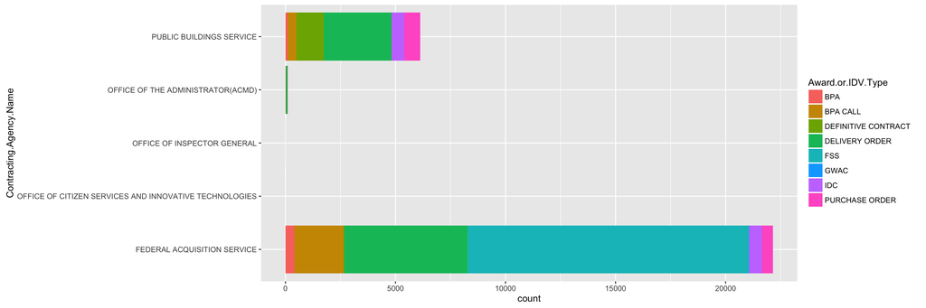

```r
#contracting agency

ggplot(dfs, aes(Contracting.Agency.Name)) +
    geom_bar(aes(fill = Award.or.IDV.Type)) +
    coord_flip()
```

Drill down to the offices within the Federal Acquisition Service.

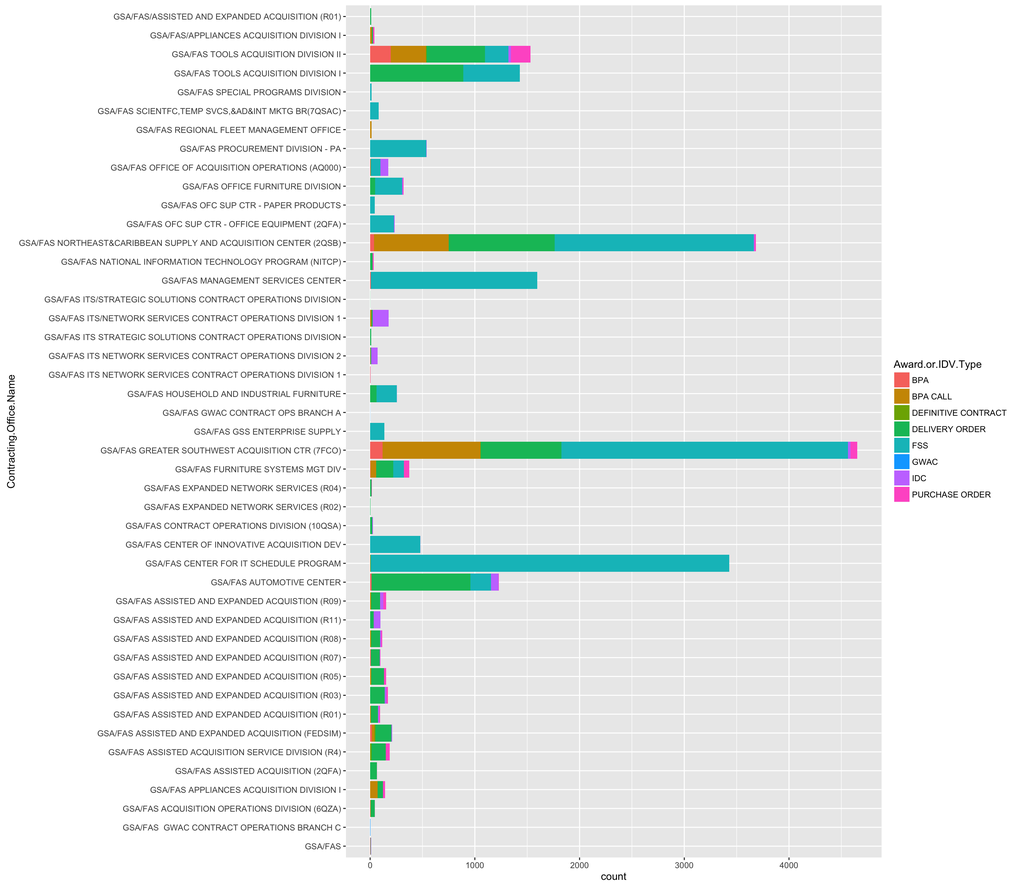

```r
#contracting agency
ggplot(filter(dfs, Contracting.Agency.Name == 'FEDERAL ACQUISITION SERVICE'),
              aes(Contracting.Office.Name)) +
    geom_bar(aes(fill = Award.or.IDV.Type)) +
    coord_flip()
```

```r
pct <- dfs %>%
    group_by(Award.or.IDV.Type) %>%
    summarise(cnt = n(), value = sum(Action.Obligation)) %>%
    mutate(propCnt = cnt / sum(cnt), propSum = value / sum(value))

pander(tbl_df(pct),split.cells=10)
```

| Award.or.IDV.Type | cnt | value | propCnt | propSum |
| --- | --- | --- | --- | --- |
| BPA | 518 | 335673.6 | 0.0182529335 | 0.0002612679 |
| BPA CALL | 2618 | 98202013.4 | 0.0922513126 | 0.0764344819 |
| DEFINITIVE CONTRACT | 1302 | 191924816.0 | 0.0458789950 | 0.1493826183 |
| DELIVERY ORDER | 8742 | 858717504.5 | 0.3080446809 | 0.6683735424 |
| FSS | 12781 | 0.0 | 0.4503682300 | 0.0000000000 |
| GWAC | 4 | 0.0 | 0.0001409493 | 0.0000000000 |
| IDC | 1192 | 73195010.4 | 0.0420028895 | 0.0569705498 |
| PURCHASE ORDER | 1222 | 62411781.6 | 0.0430600092 | 0.0485775396 |

While we’re looking at percentages let’s take a similar look at the break down of competition types.

```r
pct <- dfs %>%
    group_by(Extent.Competed) %>%
    summarise(cnt = n(), value = sum(Action.Obligation)) %>%
    mutate(propCnt = cnt / sum(cnt), propSum = value / sum(value))

pander(tbl_df(pct),hyphenate=T, split.cells=15)
```

| Extent.Competed | cnt | value | propCnt | propSum |
| --- | --- | --- | --- | --- |
|  | 279 | 4945940.5 | 0.0098312132 | 0.0038496196 |
| COMPETED UNDER SAP | 1408 | 16556507.9 | 0.0496141513 | 0.0128865800 |
| COMPETITIVE DELIVERY ORDER | 107 | 39616089.2 | 0.0037703936 | 0.0308347573 |
| FOLLOW ON TO COMPETED ACTION | 8 | 771323.5 | 0.0002818986 | 0.0006003514 |
| FULL AND OPEN COMPETITION | 21509 | 865256038.7 | 0.7579195884 | 0.6734627403 |
| FULL AND OPEN COMPETITION AFTER EXCLUSION OF SOURCES | 2162 | 173218617.7 | 0.0761830931 | 0.1348228498 |
| NON-COMPETITIVE DELIVERY ORDER | 7 | 3620636.7 | 0.0002466613 | 0.0028180837 |
| NOT AVAILABLE FOR COMPETITION | 2010 | 132844255.9 | 0.0708270200 | 0.1033978991 |
| NOT COMPETED | 256 | 27726767.7 | 0.0090207548 | 0.0215808317 |
| NOT COMPETED UNDER SAP | 633 | 20230621.8 | 0.0223052257 | 0.0157462871 |

Now we should start to explore patterns in the number of offers…